# CS 422 Section 02

Nicholas Saveas

# Exercise 1.1

I am taking this course because I feel that a career in data science would allow me to make use of both my computer science and math skills. I would like to achieve a greater understanding of what the field of data science is about and am using this course to help me determine what I would like to do with my future.

# Exercise 2.1

## 2.1-A

Load the dataset using “data(cars)” and then print it by calling it.

```r
data(cars)
cars
```

| speed | dist |
| --- | --- |
| 4 | 2 |
| 4 | 10 |
| 7 | 4 |
| 7 | 22 |
| 8 | 16 |
| 9 | 10 |
| 10 | 18 |
| 10 | 26 |
| 10 | 34 |
| 11 | 17 |

[output cut: 40 more lines]

## 2.1-B

Plot the cars dataset using the “plot(cars)” comand and then provide the graph with a “main = _" title.

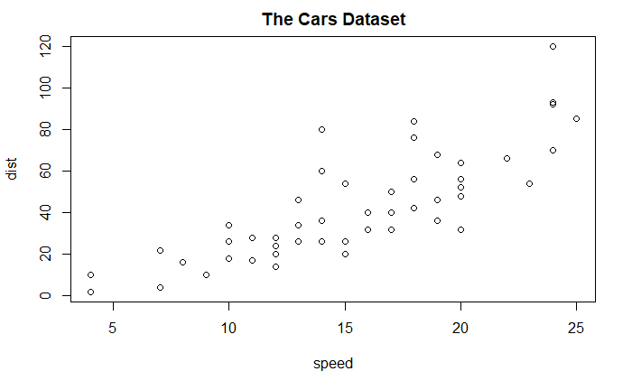

## Exercise 2.1-C

The summary() function gives you enough information to create a box plot - minimum, 1st quartile, median, 3rd quartile, and maximum. + the mean

```
     speed           dist
 Min.   : 4.0   Min.   :  2.00
 1st Qu.:12.0   1st Qu.: 26.00
 Median :15.0   Median : 36.00
 Mean   :15.4   Mean   : 42.98
 3rd Qu.:19.0   3rd Qu.: 56.00
 Max.   :25.0   Max.   :120.00
```

## Exercise 2.1-D

The maximum speed is 25.0

The minimum distance is 2.00

# Exercise 2.2

## Exercise 2.2-A

Set the working directory to where the “students.csv”" is stored. Load the dataframe and then add a new element to the dataset.

stringsAsFactors = TRUE treats strings as enumerables - categorical variable. It has to be a value in a certain limited number of variables.

| name | id | gpa | grade |
| --- | --- | --- | --- |
| Robert DeNiro | 9711 | 3.44 | B |
| Robert Downey, Jr | 33771 | 2 | C |
| Samantha Bee | 61094 | 4 | A |
| Jason Bateman | 45003 | 1 | E |
| Alicia Keyes | 55101 | 3.92 | B |
| Denzel Washington | 71005 | 4 | A |
| Joaquin Phoenix | 41180 | 2.89 | C |
| Brad Pitt | 40051 | 2.21 | C |